# Blood donation solution using Neural Networks

## Description

Use information about each donor’s history:

- Months since Last Donation: this is the number of monthis since this donor’s most recent donation.
- Number of Donations: this is the total number of donations that the donor has made.
- Total Volume Donated: this is the total amound of blood that the donor has donated in cubuc centimeters.
- Months since First Donation: this is the number of months since the donor’s first donation.

## Problems

1. BUILD A PREDICTING MODEL BASED ON DONOR’S HISTORY AND OUTCOME OF MADE DONATION IN MARCH 2007
2. USING MODEL BUILT IN PROBLEM 1, PREDICT THE OUTCOME OF DONATIONS IN NEXT BLOOD DONATION CAMPAIGN (Assume that next donation will be on May 2007)

## Solution

### Load and prepare blood donation dataset

Load the training dataset into data frame `bd`

```r
bd <- read.csv('blood_donation.csv')
head(bd)
```

```
##     X Months.since.Last.Donation Number.of.Donations
## 1 619                          2                  50
## 2 664                          0                  13
## 3 441                          1                  16
## 4 160                          2                  20
## 5 358                          1                  24
## 6 335                          4                   4
##   Total.Volume.Donated..c.c.. Months.since.First.Donation
## 1                       12500                          98
## 2                        3250                          28
## 3                        4000                          35
## 4                        5000                          45
## 5                        6000                          77
## 6                        1000                           4
##   Made.Donation.in.March.2007
## 1                           1
## 2                           1
## 3                           1
## 4                           1
## 5                           0
## 6                           0
```

```r
str(bd)
```

```
## 'data.frame':    376 obs. of  6 variables:
##  $ X                          : int  619 664 441 160 358 335 47 164 736 436 ...
##  $ Months.since.Last.Donation : int  2 0 1 2 1 4 2 1 5 0 ...
##  $ Number.of.Donations        : int  50 13 16 20 24 4 7 12 46 3 ...
##  $ Total.Volume.Donated..c.c..: int  12500 3250 4000 5000 6000 1000 1750 3000 11500 750 ...
##  $ Months.since.First.Donation: int  98 28 35 45 77 4 14 35 98 4 ...
##  $ Made.Donation.in.March.2007: int  1 1 1 1 0 0 1 0 1 0 ...
```

### Explore the distributed single variable plot

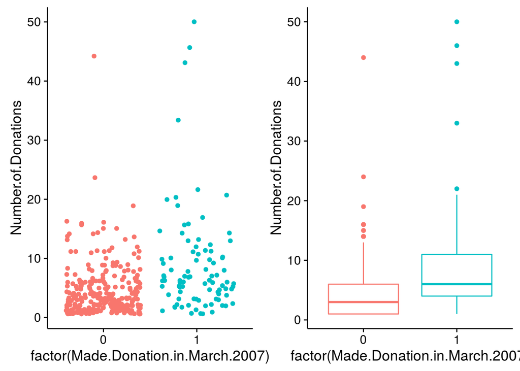

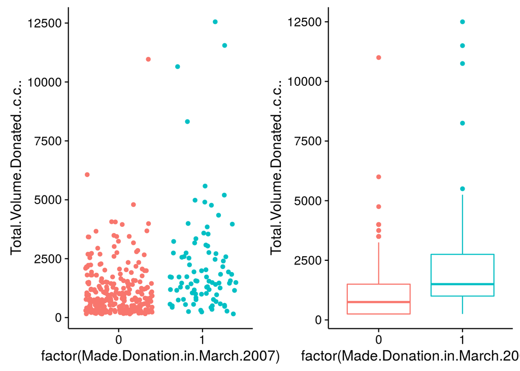

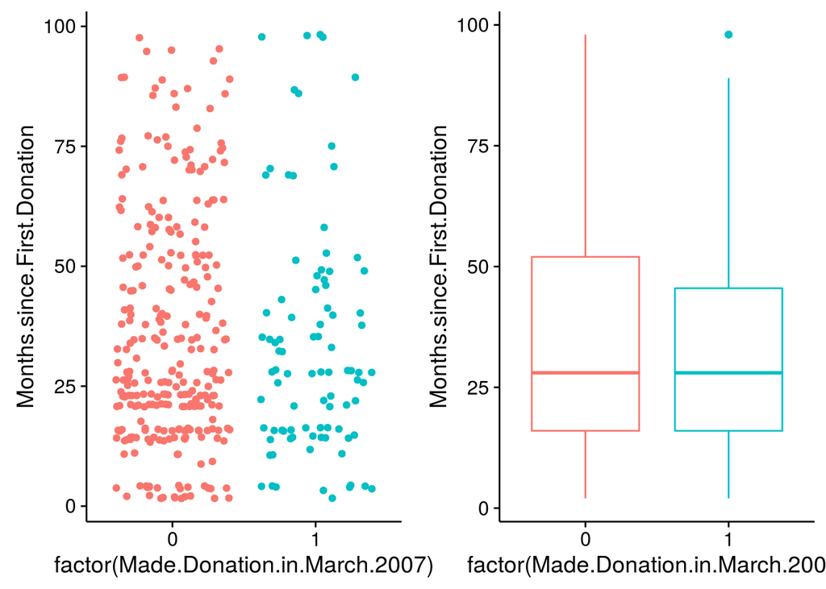

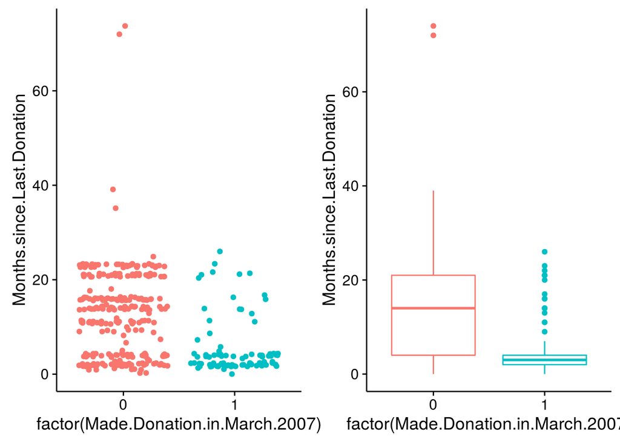

### Explore the 2 variables combination plot

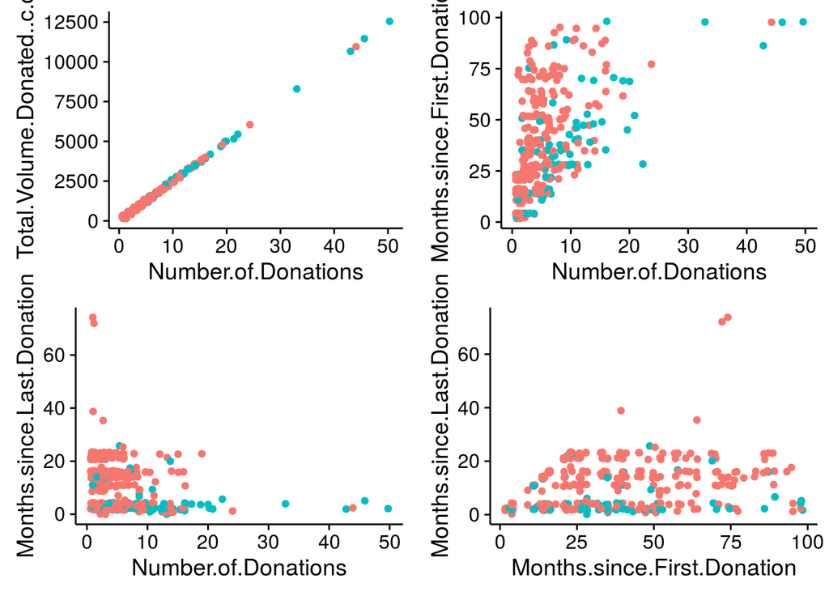

**Summary:**

- Two variables `Number.of.Donations` and `Total.Volume.Donated..c.c..` strictly linearly dependent to each other so we could remove one of these out of dataset without decreasing effectiveness of our predicting model
- Since the data points are not linearly separated, we should introduce some features to help the predicting model, namely `DonationPerMonth` and `MonthPerDonation` computed as follow:

### Prepare the training dataset

```r
prepare <- function (data) {
  data %>%
  rename(MonthsLD = Months.since.Last.Donation,
         NumberDonations = Number.of.Donations,
         TotalVolume = Total.Volume.Donated..c.c..,
         MonthsFD = Months.since.First.Donation,
         March.2007 = Made.Donation.in.March.2007) %>%
  # mutate(March.2007 = as.factor(March.2007)) %>%
  mutate(DonateDuration = MonthsFD - MonthsLD + 1) %>%
  mutate(DonationsPerMonth = NumberDonations / DonateDuration) %>%
  mutate(MonthsPerDonation = DonateDuration / NumberDonations) %>%
  select(NumberDonations,
         MonthsFD,
         MonthsLD,
         # TotalVolume,
         # DonateDuration,
         DonationsPerMonth,
         MonthsPerDonation,
         March.2007)
}
bd.prepared <- prepare(bd)
head(bd.prepared)
```

```
##   NumberDonations MonthsFD MonthsLD DonationsPerMonth MonthsPerDonation
## 1              50       98        2         0.5154639          1.940000
## 2              13       28        0         0.4482759          2.230769
## 3              16       35        1         0.4571429          2.187500
## 4              20       45        2         0.4545455          2.200000
## 5              24       77        1         0.3116883          3.208333
## 6               4        4        4         4.0000000          0.250000
##   March.2007
## 1          1
## 2          1
## 3          1
## 4          1
## 5          0
## 6          0
```

```r
str(bd.prepared)
```

```
## 'data.frame':    376 obs. of  6 variables:
##  $ NumberDonations  : int  50 13 16 20 24 4 7 12 46 3 ...
##  $ MonthsFD         : int  98 28 35 45 77 4 14 35 98 4 ...
##  $ MonthsLD         : int  2 0 1 2 1 4 2 1 5 0 ...
##  $ DonationsPerMonth: num  0.515 0.448 0.457 0.455 0.312 ...
##  $ MonthsPerDonation: num  1.94 2.23 2.19 2.2 3.21 ...
##  $ March.2007       : int  1 1 1 1 0 0 1 0 1 0 ...
```

Split the original training set into training and validation sets

```r
n <- nrow(bd.prepared)
s <- sample(1:n, 2*n/3)
bd.train <- bd.prepared[s,]
head(bd.train)
```

```
##     NumberDonations MonthsFD MonthsLD DonationsPerMonth MonthsPerDonation
## 126               4       57       14        0.09090909                11
## 159               5       60       21        0.12500000                 8
## 269               1        4        4        1.00000000                 1
## 329               3       37       11        0.11111111                 9
## 273               1        4        4        1.00000000                 1
## 141               3       76       11        0.04545455                22
##     March.2007
## 126          0
## 159          0
## 269          0
## 329          0
## 273          0
## 141          0
```

```r
bd.validate <- bd.prepared[-s,]
head(bd.validate)
```

```
##    NumberDonations MonthsFD MonthsLD DonationsPerMonth MonthsPerDonation
## 1               50       98        2         0.5154639          1.940000
## 3               16       35        1         0.4571429          2.187500
## 6                4        4        4         4.0000000          0.250000
## 8               12       35        1         0.3428571          2.916667
## 13               6       15        2         0.4285714          2.333333
## 14               5       11        2         0.5000000          2.000000
##    March.2007
## 1           1
## 3           1
## 6           0
## 8           0
## 13          1
## 14          1
```

#### Logistic model

First we will train a simple logistic model first to compare with neural network later on

```r
bd.logis <- glm(data = bd.train,
                March.2007 ~ NumberDonations + MonthsFD + MonthsLD + DonationsPerMonth + MonthsPerDonation,
                family = binomial)

summary(bd.logis)
```

```
##
## Call:
## glm(formula = March.2007 ~ NumberDonations + MonthsFD + MonthsLD +
##     DonationsPerMonth + MonthsPerDonation, family = binomial,
##     data = bd.train)
##
## Deviance Residuals:
##      Min        1Q    Median        3Q       Max
## -2.18387  -0.69650  -0.35962  -0.06704   2.47420
##
## Coefficients:
##                    Estimate Std. Error z value Pr(>|z|)
## (Intercept)        0.363737   0.672940   0.541  0.58884
## NumberDonations    0.055083   0.065110   0.846  0.39755
## MonthsFD           0.004389   0.020428   0.215  0.82988
## MonthsLD          -0.127898   0.036799  -3.476  0.00051 ***
## DonationsPerMonth -0.380910   0.479935  -0.794  0.42739
## MonthsPerDonation -0.227242   0.137218  -1.656  0.09771 .
## ---
## Signif. codes:  0 '***' 0.001 '**' 0.01 '*' 0.05 '.' 0.1 ' ' 1
##
## (Dispersion parameter for binomial family taken to be 1)
##
##     Null deviance: 265.96  on 249  degrees of freedom
## Residual deviance: 209.44  on 244  degrees of freedom
## AIC: 221.44
##
## Number of Fisher Scoring iterations: 6
```

```r
bd.logis.predict <- predict(bd.logis, bd.validate, type = "response")

CrossTable(x = bd.validate$March.2007, y = round(bd.logis.predict), prop.chisq = TRUE)
```

```
##
##
##    Cell Contents
## |-------------------------|
## |                       N |
## | Chi-square contribution |
## |           N / Row Total |
## |           N / Col Total |
## |         N / Table Total |
## |-------------------------|
##
##
## Total Observations in Table:  126
##
##
##                        | round(bd.logis.predict)
## bd.validate$March.2007 |         0 |         1 | Row Total |
## -----------------------|-----------|-----------|-----------|
##                      0 |        89 |         2 |        91 |
##                        |     0.063 |     1.256 |           |
##                        |     0.978 |     0.022 |     0.722 |
##                        |     0.742 |     0.333 |           |
##                        |     0.706 |     0.016 |           |
## -----------------------|-----------|-----------|-----------|
##                      1 |        31 |         4 |        35 |
##                        |     0.163 |     3.267 |           |
##                        |     0.886 |     0.114 |     0.278 |
##                        |     0.258 |     0.667 |           |
##                        |     0.246 |     0.032 |           |
## -----------------------|-----------|-----------|-----------|
##           Column Total |       120 |         6 |       126 |
##                        |     0.952 |     0.048 |           |
## -----------------------|-----------|-----------|-----------|
##
##
```

#### Neural networks

```r
bd.nn <- neuralnet(March.2007 ~ NumberDonations + MonthsFD + MonthsLD + DonationsPerMonth + MonthsPerDonation,
                   bd.train, act.fct = "logistic", hidden = c(3), threshold = 0.01, stepmax = 10000)

summary(bd.nn)
```

```
##                     Length Class      Mode
## call                   7   -none-     call
## response             250   -none-     numeric
## covariate           1250   -none-     numeric
## model.list             2   -none-     list
## err.fct                1   -none-     function
## act.fct                1   -none-     function
## linear.output          1   -none-     logical
## data                   6   data.frame list
## net.result             1   -none-     list
## weights                1   -none-     list
## startweights           1   -none-     list
## generalized.weights    1   -none-     list
## result.matrix         25   -none-     numeric
```

```r
bd.nn.predict <- neuralnet::compute(bd.nn, select(bd.validate,
                                                  NumberDonations,
                                                  MonthsFD,
                                                  MonthsLD,
                                                  DonationsPerMonth,
                                                  MonthsPerDonation))

bd.nn.predict.result <- round(bd.nn.predict$net.result)

CrossTable(x = bd.validate$March.2007, y = bd.nn.predict.result, prop.chisq = TRUE)
```

```
##
##
##    Cell Contents
## |-------------------------|
## |                       N |
## | Chi-square contribution |
## |           N / Row Total |
## |           N / Col Total |
## |         N / Table Total |
## |-------------------------|
##
##
## Total Observations in Table:  126
##
##
##                        | bd.nn.predict.result
## bd.validate$March.2007 |         0 |         1 | Row Total |
## -----------------------|-----------|-----------|-----------|
##                      0 |        79 |        12 |        91 |
##                        |     3.015 |     7.538 |           |
##                        |     0.868 |     0.132 |     0.722 |
##                        |     0.878 |     0.333 |           |
##                        |     0.627 |     0.095 |           |
## -----------------------|-----------|-----------|-----------|
##                      1 |        11 |        24 |        35 |
##                        |     7.840 |    19.600 |           |
##                        |     0.314 |     0.686 |     0.278 |
##                        |     0.122 |     0.667 |           |
##                        |     0.087 |     0.190 |           |
## -----------------------|-----------|-----------|-----------|
##           Column Total |        90 |        36 |       126 |
##                        |     0.714 |     0.286 |           |
## -----------------------|-----------|-----------|-----------|
##
##
```

## Testing

Load and prepare the testing dataset into data frame `bd.test`

```r
bd.test <- read.csv('blood_donation_test.csv')
bd.test <- prepare(bd.test)
head(bd)
```

```
##     X Months.since.Last.Donation Number.of.Donations
## 1 619                          2                  50
## 2 664                          0                  13
## 3 441                          1                  16
## 4 160                          2                  20
## 5 358                          1                  24
## 6 335                          4                   4
##   Total.Volume.Donated..c.c.. Months.since.First.Donation
## 1                       12500                          98
## 2                        3250                          28
## 3                        4000                          35
## 4                        5000                          45
## 5                        6000                          77
## 6                        1000                           4
##   Made.Donation.in.March.2007
## 1                           1
## 2                           1
## 3                           1
## 4                           1
## 5                           0
## 6                           0
```

```r
str(bd)
```

```
## 'data.frame':    376 obs. of  6 variables:
##  $ X                          : int  619 664 441 160 358 335 47 164 736 436 ...
##  $ Months.since.Last.Donation : int  2 0 1 2 1 4 2 1 5 0 ...
##  $ Number.of.Donations        : int  50 13 16 20 24 4 7 12 46 3 ...
##  $ Total.Volume.Donated..c.c..: int  12500 3250 4000 5000 6000 1000 1750 3000 11500 750 ...
##  $ Months.since.First.Donation: int  98 28 35 45 77 4 14 35 98 4 ...
##  $ Made.Donation.in.March.2007: int  1 1 1 1 0 0 1 0 1 0 ...
```

Test the logistic model

```r
bd.logis.test <- predict(bd.logis, bd.test, type = "response")

CrossTable(x = bd.test$March.2007, y = round(bd.logis.test), prop.chisq = TRUE)
```

```
##
##
##    Cell Contents
## |-------------------------|
## |                       N |
## | Chi-square contribution |
## |           N / Row Total |
## |           N / Col Total |
## |         N / Table Total |
## |-------------------------|
##
##
## Total Observations in Table:  200
##
##
##                    | round(bd.logis.test)
## bd.test$March.2007 |         0 |         1 | Row Total |
## -------------------|-----------|-----------|-----------|
##                  0 |       152 |         1 |       153 |
##                    |     0.000 |     0.072 |           |
##                    |     0.993 |     0.007 |     0.765 |
##                    |     0.764 |     1.000 |           |
##                    |     0.760 |     0.005 |           |
## -------------------|-----------|-----------|-----------|
##                  1 |        47 |         0 |        47 |
##                    |     0.001 |     0.235 |           |
##                    |     1.000 |     0.000 |     0.235 |
##                    |     0.236 |     0.000 |           |
##                    |     0.235 |     0.000 |           |
## -------------------|-----------|-----------|-----------|
##       Column Total |       199 |         1 |       200 |
##                    |     0.995 |     0.005 |           |
## -------------------|-----------|-----------|-----------|
##
##
```

Compare with neural networks

```r
bd.nn.test <- neuralnet::compute(bd.nn, select(bd.test,
                                               NumberDonations,
                                               MonthsFD,
                                               MonthsLD,
                                               DonationsPerMonth,
                                               MonthsPerDonation))

bd.nn.test.result <- round(bd.nn.test$net.result)

CrossTable(x = bd.test$March.2007, y = bd.nn.test.result, prop.chisq = TRUE)
```

```
##
##
##    Cell Contents
## |-------------------------|
## |                       N |
## | Chi-square contribution |
## |           N / Row Total |
## |           N / Col Total |
## |         N / Table Total |
## |-------------------------|
##
##
## Total Observations in Table:  200
##
##
##                    | bd.nn.test.result
## bd.test$March.2007 |         0 |         1 | Row Total |
## -------------------|-----------|-----------|-----------|
##                  0 |       117 |        36 |       153 |
##                    |     0.080 |     0.233 |           |
##                    |     0.765 |     0.235 |     0.765 |
##                    |     0.785 |     0.706 |           |
##                    |     0.585 |     0.180 |           |
## -------------------|-----------|-----------|-----------|
##                  1 |        32 |        15 |        47 |
##                    |     0.260 |     0.758 |           |
##                    |     0.681 |     0.319 |     0.235 |
##                    |     0.215 |     0.294 |           |
##                    |     0.160 |     0.075 |           |
## -------------------|-----------|-----------|-----------|
##       Column Total |       149 |        51 |       200 |
##                    |     0.745 |     0.255 |           |
## -------------------|-----------|-----------|-----------|
##
##
```

## Problem 2: using model built in problem 1, predict the outcome of donations in next blood donation campaign

Modify the original `bd` dataset to reflect accumulative data at May 2007

- If person donate at March 2007 (`Made.Donation.in.March.2007` equal 1) then his/her `Number.of.Donations` will increase by 1 and `Months.since.Last.Donation` will be reset to 2
- If person not join the donation at March 2007 then his/her `Number.of.Donations` remain the same and `Months.since.Last.Donation` will increase by 2

```r
bd2 <- bd %>%
  mutate(Months.since.First.Donation = Months.since.First.Donation + 2) %>%
  mutate(Months.since.Last.Donation = if_else(Made.Donation.in.March.2007 == 1,
                                              2, Months.since.Last.Donation + 2)) %>%
  mutate(Number.of.Donations = Number.of.Donations + Made.Donation.in.March.2007) %>%
  prepare()
```

Predict the outcome of donation at May 2007 using the previous neural networks

```r
bd2.predict <- neuralnet::compute(bd.nn, select(bd2,
                                                NumberDonations,
                                                MonthsFD,
                                                MonthsLD,
                                                DonationsPerMonth,
                                                MonthsPerDonation))

bd2.predict.df <- data.frame(probability = bd2.predict$net.result,
                             prediction = round(bd2.predict$net.result))
summary(bd2.predict.df)
```

```
##   probability           prediction
##  Min.   :0.05207995   Min.   :0.0000000
##  1st Qu.:0.05207995   1st Qu.:0.0000000
##  Median :0.05207995   Median :0.0000000
##  Mean   :0.21380506   Mean   :0.3191489
##  3rd Qu.:0.54281017   3rd Qu.:1.0000000
##  Max.   :0.54283331   Max.   :1.0000000
```